# Noise_data_preparation

Tino Schneidewind

2025-05-09

Amended in July 2026 by Apolline Saucy

### Aim of the document

In this RMarkdown I will implement the data preparation of the noise sentry data for the analysis following the steps provided by Apolline Saucy. For this trial, I will utilise only noise data from one participant of the first week (001).

```
## # A tibble: 6 × 6
##   uid     datetime               NS NS_MA  hour   dow
##   <chr>   <dttm>              <dbl> <dbl> <int> <dbl>
## 1 ACT001D 2024-12-02 09:02:00  53.4  55.4     9     1
## 2 ACT001D 2024-12-02 09:03:00  54.6  56.3     9     1
## 3 ACT001D 2024-12-02 09:04:00  53.1  57.7     9     1
## 4 ACT001D 2024-12-02 09:05:00  56.5  57.7     9     1
## 5 ACT001D 2024-12-02 09:06:00  52.5  57.4     9     1
## 6 ACT001D 2024-12-02 09:07:00  54.2  57.6     9     1
```

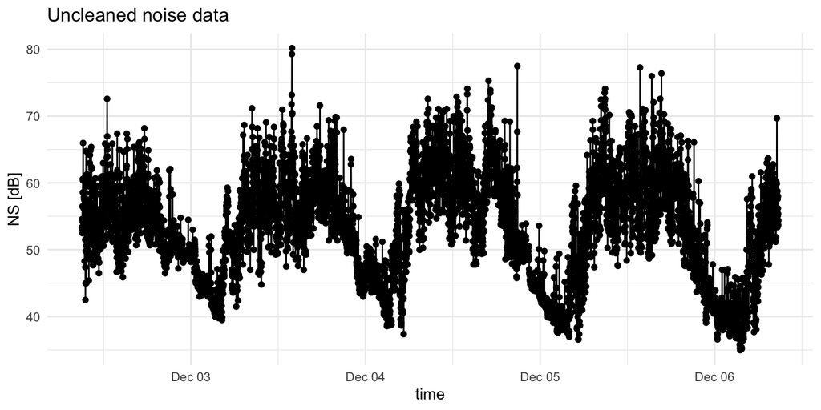

##### 1) Clean the raw data

as described in [Land Use Regression Modeling of Outdoor Noise Exposure in Informal Settlements in Western Cape, South Africa](https://www.mdpi.com/1660-4601/14/10/1262)

1. restrict to the same weekly period for everyone. Identify start and end times for which everyone is being monitored. Time windows can be discussed based on data availability.

Tuesday 6 am to saturday 6 am

```r
data_N_001 <- data_N_001 |>
  filter(
    (dow == 2 & hour >= 6) |  # Tuesday from 6am
      (dow %in% 3:5) |        # Tuesday to Thursday
      (dow == 6 & hour < 6) # Saturday up to 6am
  )
```

2. Exclude observations with >10% missing data (threshold to discuss depending on data availability)

```r
NA_perc = mean(is.na(data_N_001$NS))

if(NA_perc > .1){
  data_N_001$NS = NA
}
```

3. Remove outliers, defined as one-minute noise measurements (=raw data) exceeding the five-day mean by plus or minus three standard deviations.

```r
mean_noise = mean(data_N_001$NS, na.rm = TRUE)
sd_noise = sd(data_N_001$NS, na.rm = TRUE) * 3

data_N_001 <- data_N_001 |>
  mutate(
    NS_outliers = ifelse(NS > mean_noise + sd_noise | NS < mean_noise - sd_noise, TRUE, FALSE)
  )
```

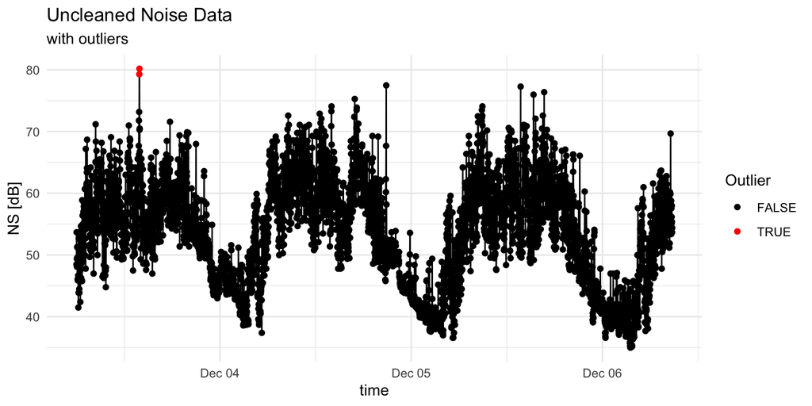

##### 2) Calculate noise indicators (long-term)

A-weighted equivalent sound level variables as described here: [Space-time characterization of community noise and sound sources in Accra, Ghana | Scientific Reports](https://www.nature.com/articles/s41598-021-90454-6#Fig1)

```r
data_N_001 <- data_N_001 |>
  mutate(
    NS_clean = ifelse(NS_outliers == TRUE, NA, NS)
  )
```

1. calculate L_Aeq and intermittency ratios for each site and date of measurement

```r
# total
L_Aeq_tot = 10 * log10( mean(10^(0.1 * data_N_001$NS_clean), na.rm = TRUE ) )

# hourly
noise_ind_hourly <- data_N_001 |>
  group_by(dow, hour) |>

  # A-weighted equivalent continuous hourly sound levels L_Aeq_1h
  summarize(L_Aeq_1h = 10 * log10( mean(10^(0.1 * NS_clean), na.rm = TRUE ) ),
            .groups = "drop")
```

[figure not shown]

```r
# daily data frame
noise_ind_daily <- data_N_001 |>
  group_by(dow) |>

      mutate(
      energy = 10^(0.1 * NS) # work on energy level (linear) before going back to decibel scale
    )|>
    summarize(

      # LAeq --------------------
      L_Aeq_tot = 10 * log10(mean(energy, na.rm = TRUE)),
      L_Aeq_day = 10 * log10(mean(energy[hour >= 6 & hour < 22], na.rm = TRUE)),
      L_Aeq_night = 10 * log10(mean(energy[hour < 6 | hour >= 22], na.rm = TRUE)),

      # IR 24h --------------------
      IR_24h = {
        Ltot <- 10 * log10(mean(energy, na.rm = TRUE))
        K <- Ltot + 3 # threshold is average sound level + 3
        idx <- NS >= K # identify observations which overpass threshold K
        sum(energy[idx], na.rm = TRUE) / sum(energy, na.rm = TRUE) # IR is the proportion of overall energy of the events to the overall weekly energy
      },

      # IR day ------------------
      IR_day = {
        sel <- hour >= 6 & hour < 22
        x_energy <- energy[sel]
        x_NS <- NS[sel]
        Ltot <- 10 * log10(mean(x_energy, na.rm = TRUE))
        K <- Ltot + 3
        idx <- x_NS >= K
        sum(x_energy[idx], na.rm = TRUE) / sum(x_energy, na.rm = TRUE)
      },

      # IR night ------------------
      IR_night = {
        sel <- hour < 6 | hour >= 22
        x_energy <- energy[sel]
        x_NS <- NS[sel]
        Ltot <- 10 * log10(mean(x_energy, na.rm = TRUE))
        K <- Ltot + 3
        idx <- x_NS >= K
        sum(x_energy[idx], na.rm = TRUE) / sum(x_energy, na.rm = TRUE)
      },

      # L_den ------------------
      L_den_day = 10 * log10(mean(energy[hour >= 6 & hour < 18], na.rm = TRUE)),
      L_den_eve = 10 * log10(mean(energy[hour >= 18 & hour < 22], na.rm = TRUE)),
      L_den_nig = 10 * log10(mean(energy[hour < 6 | hour >= 22], na.rm = TRUE)),

      L_den = 10 * log10(
        (1/24) *
          (12 * 10^(L_den_day / 10) +
             4  * 10^((L_den_eve + 5) / 10) +
             8  * 10^((L_den_nig + 10) / 10))
      ),

      .groups = "drop"
)


# weekly data frame
noise_ind_weekly <- data_N_001 |>
      mutate(
      energy = 10^(0.1 * NS) # work on energy level (linear) before going back to decibel scale
    )|>
    summarize(

      # LAeq --------------------
      L_Aeq_tot = 10 * log10(mean(energy, na.rm = TRUE)),
      L_Aeq_day = 10 * log10(mean(energy[hour >= 6 & hour < 22], na.rm = TRUE)),
      L_Aeq_night = 10 * log10(mean(energy[hour < 6 | hour >= 22], na.rm = TRUE)),

      # IR 24h --------------------
      IR_24h = {
        Ltot <- 10 * log10(mean(energy, na.rm = TRUE))
        K <- Ltot + 3 # threshold is average sound level + 3
        idx <- NS >= K # identify observations which overpass threshold K
        sum(energy[idx], na.rm = TRUE) / sum(energy, na.rm = TRUE) # IR is the proportion of overall energy of the events to the overall weekly energy
      },

      # IR day ------------------
      IR_day = {
        sel <- hour >= 6 & hour < 22
        x_energy <- energy[sel]
        x_NS <- NS[sel]
        Ltot <- 10 * log10(mean(x_energy, na.rm = TRUE))
        K <- Ltot + 3
        idx <- x_NS >= K
        sum(x_energy[idx], na.rm = TRUE) / sum(x_energy, na.rm = TRUE)
      },

      # IR night ------------------
      IR_night = {
        sel <- hour < 6 | hour >= 22
        x_energy <- energy[sel]
        x_NS <- NS[sel]
        Ltot <- 10 * log10(mean(x_energy, na.rm = TRUE))
        K <- Ltot + 3
        idx <- x_NS >= K
        sum(x_energy[idx], na.rm = TRUE) / sum(x_energy, na.rm = TRUE)
      },

      # L_den ------------------
      L_den_day = 10 * log10(mean(energy[hour >= 6 & hour < 18], na.rm = TRUE)),
      L_den_eve = 10 * log10(mean(energy[hour >= 18 & hour < 22], na.rm = TRUE)),
      L_den_nig = 10 * log10(mean(energy[hour < 6 | hour >= 22], na.rm = TRUE)),

      L_den = 10 * log10(
        (1/24) *
          (12 * 10^(L_den_day / 10) +
             4  * 10^((L_den_eve + 5) / 10) +
             8  * 10^((L_den_nig + 10) / 10))
      ),

      .groups = "drop"
    )
```

##### 3) Additional cleaning step: clean hourly averages

Hourly averages (LAeq_hourly and IR_hourly) were visualized for each individual and monitoring week (Tuckey plots). Hourly values that exceeded 1.5*IQR of the distribution for a specific hour of the day within each monitoring week was excluded. This was done to eliminate extreme values that may not be representative of long- to mid-term community noise exposure at a given location and time.

###### “simple outlier exclusion

[figure not shown]

###### 1h Tuckey IQR exclusion

[figure not shown]

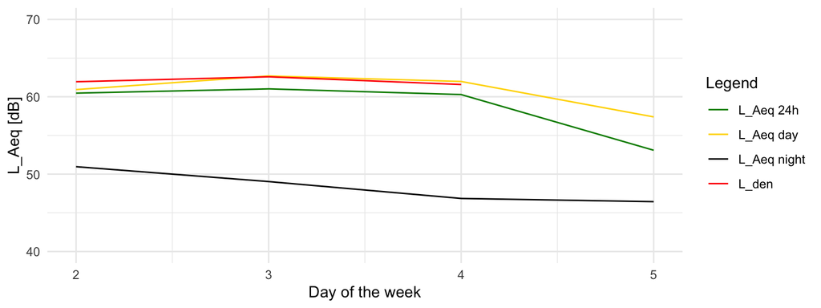

[figure not shown]